# Spatial Turnover Exploratory Analysis

Instructions from Malin:

Is anyone up for an exploratory analysis with the trawl data? It would be very cool to look at changes in spatial turnover, similar to [Magurran, Dornelas, Moyes, Gotelli, McGill et al. 2015](http://www.nature.com/ncomms/2015/150924/ncomms9405/full/ncomms9405.html) but across a much wider set of regions. An idea from conversations at [HIFMB](https://hifmb.de/en/) yesterday.

From Magurran et al. *“Here, we analyse an exceptionally comprehensive 29-year time series of North Atlantic groundfish assemblages monitored over 5° latitude to the west of Scotland. These fish assemblages show no systematic change in species richness through time, but steady change in species composition, leading to an increase in spatial homogenization: the species identity of colder northern localities increasingly resembles that of warmer southern localities.”*

Methods from Magurran et al. 2015

- First assign the rectangles to nine 30’ latitudinal bands
- Compile community time series for each latitudinal band
- Sample rarefaction ensures equal sampling effort across bands and is used in the calculation of temporal $\alpha$ diversity and temporal $\beta$ diversity.
- First calculate dissimilarity in relation to the start of the survey
- Next, for each year, we compute pairwise compositional dissimilarity of these latitudinal bands
- We also construct distance-decay plots for each year

```r
library(data.table)
library(vegan)
library(ggpubr)
library(betapart)
```

Download data from Ocean Adapt. Accessed January 1 2020. [NEUS Strata](https://github.com/pinskylab/OceanAdapt/blob/master/data_raw/neus_strata.csv) [NEUS SVPP](https://github.com/pinskylab/OceanAdapt/blob/master/data_raw/neus_SVSPP.RData) [NEUS Survey Data](https://github.com/pinskylab/OceanAdapt/blob/master/data_raw/neus_Survdat.RData)

```r
#neus_strata <- read.csv("neus_strata.csv")
#save(neus_strata, file = "neus_strata.RData")
load("neus_strata.Rdata")
load("neus_Survdat.RData")
load("neus_SVSPP.RData")
```

Extract columns we actually need

```r
neus_strata.r <- data.table(neus_strata[,c(2:3)]) #STRATUM, STRATUM NAME
neus_survdat.r <- data.table(survdat[,c(3,5,8:11)]) #STRATUM, SVSPP, YEAR, SEASON, LAT, LON
neus_spp.r <- data.table(spp[,c(1,2,4)]) #SCINAME, SVSPP, COMNAME
neus_spp.r
```

| SCINAME | SVSPP | COMNAME |
| --- | --- | --- |
| UNIDENTIFIED FISH | 0 | UNCLASSIFIED FISH |
| MYXINE GLUTINOSA | 1 | ATLANTIC HAGFISH |
| PETROMYZON MARINUS | 2 | SEA LAMPREY |
| CARCHARHINUS OBSCURUS | 3 | DUSKY SHARK |
| DASYATIS CENTROURA | 4 | ROUGHTAIL STINGRAY |
| RAJIFORMES | 5 | RAY AND SKATE UNCL |
| CETORHINUS MAXIMUS | 6 | BASKING SHARK |
| CENTROSCYLLIUM FABRICII | 7 | BLACK DOGFISH |
| ETMOPTERUS PRINCEPS | 8 | ROUGH SAGRE |
| CARCHARHINUS PLUMBEUS | 9 | SANDBAR SHARK |

[output cut: 808 more lines]

```r
stratamerge <- neus_survdat.r[neus_strata.r, on = "STRATUM"] #merge strata with survey data
neus_full <- stratamerge[neus_spp.r, on = "SVSPP"] #merge species with strata and survey data
neus_full
```

| STRATUM | SVSPP | YEAR | SEASON | LAT | LON | STRATUM_NAME | SCINAME | COMNAME |
| --- | --- | --- | --- | --- | --- | --- | --- | --- |
| 1030 | 0 | 1969 | FALL | 39.70000 | -72.01667 | SNE HUDSON CANYN | UNIDENTIFIED FISH | UNCLASSIFIED FISH |
| 1030 | 0 | 1999 | SPRING | 39.89550 | -71.88400 | SNE HUDSON CANYN | UNIDENTIFIED FISH | UNCLASSIFIED FISH |
| 1030 | 0 | 1999 | SPRING | 39.86083 | -71.85033 | SNE HUDSON CANYN | UNIDENTIFIED FISH | UNCLASSIFIED FISH |
| 1030 | 0 | 2000 | SPRING | 39.65200 | -72.24233 | SNE HUDSON CANYN | UNIDENTIFIED FISH | UNCLASSIFIED FISH |
| 1040 | 0 | 1969 | FALL | 39.20000 | -72.50000 | SNE HUDSON CANYN | UNIDENTIFIED FISH | UNCLASSIFIED FISH |
| 1040 | 0 | 1972 | SPRING | 39.28333 | -72.33333 | SNE HUDSON CANYN | UNIDENTIFIED FISH | UNCLASSIFIED FISH |
| 1040 | 0 | 1974 | FALL | 39.51667 | -72.35000 | SNE HUDSON CANYN | UNIDENTIFIED FISH | UNCLASSIFIED FISH |
| 1040 | 0 | 1974 | FALL | 39.51667 | -72.35000 | SNE HUDSON CANYN | UNIDENTIFIED FISH | UNCLASSIFIED FISH |
| 1040 | 0 | 1974 | FALL | 39.51667 | -72.35000 | SNE HUDSON CANYN | UNIDENTIFIED FISH | UNCLASSIFIED FISH |
| 1040 | 0 | 1974 | FALL | 39.51667 | -72.35000 | SNE HUDSON CANYN | UNIDENTIFIED FISH | UNCLASSIFIED FISH |

[output cut: 990 more lines]

Make sure every observation is of an identifiable fish, aka SVSPP != 0

```r
neus_full.ID <- neus_full[SVSPP != 0,]
```

Group Stratums

For now, I will split into MAB, SNE, GB, and GOM

From Michelle’s metadata:

Stratum group code: 01 = Trawl, offshore north of Hatteras; 03 = Trawl, inshore north of Hatteras; 05 = Scotian shelf; 07 = Trawl, inshore south of Hatteras; 08 = Trawl, Offshore south of Hatteras;

# we only want 01 and 03’s

```r
#neus_full.ID.0103 <- neus_full.ID[STRATUM < 4000] not doing this any more, instead will reduce using below
```

Region Stratum Key

```r
region_strata_key <- data.table(read.csv("key_reg_strata.csv"))
```

```r
neus_full.ID.regions <- neus_full.ID[region_strata_key, on = "STRATUM_NAME"]
neus_full.ID.regions.r <- na.omit(neus_full.ID.regions, cols = "reg") #get rid of all rows without a reg
summary(neus_full.ID.regions.r$reg)
```

```
   GEO    GME    MAB    SNE
486159 850933 704043 708479
```

Find center point of trawls in each region to find distance between regions

```r
library(geosphere)
library(rgeos)
latlon_reg <- na.omit(unique(neus_full.ID.regions.r, by = c("LAT", "LON")), c("LAT", "LON")) # single lat lon for each, to reduce bias, also, get rid of single NA row for Lat and Lon
# Define centroid function - Lon is first argument and Lat is second
# Geosphere takes a matrix with two columns: Lon|Lat, so we use cbind to coerce the data to this form
findCentroid <- function(LON, LAT, ...){
  centroid(cbind(LON, LAT), ...)
}
# Find centroid Lon and Lat by ID, as required
latlon_reg[, c("Cent_lon", "Cent_lat") := as.list(findCentroid(LON, LAT)), by = reg] #I will get an error on this when there are NA's in the LAT LON columns
reg_centroids <- unique(latlon_reg, by = c("Cent_lon", "Cent_lat"))
reg_centroids <- reg_centroids[, 13:15] #columns I need
#reorder so in order from N to S
reg_centroids[, reg := factor(reg, levels = c("GME", "GEO", "SNE", "MAB"))]
setorder(reg_centroids, reg) #set to this new factor level order
#the location of MAB still doesn't make sense (too far south), but I'm moving forward anyway, much better than before
```

```r
#one PRESENT value for each YEAR, SEASON, reg, and SVSPP combination
neus_full.ID.regions.unique <- unique(neus_full.ID.regions, by = c("YEAR", "reg", "SVSPP")) #unique mini-region, year, species combinations
#reduce data table to just be svspp, year, sciname, comname, reg
neus_full.ID.regions.unique.r <- data.table(na.omit(neus_full.ID.regions.unique[, c("SVSPP", "SCINAME", "COMNAME", "YEAR", "reg")], col = "YEAR"))
#add presence column
neus_full.ID.regions.unique.r[,"present" := 1]
#now I need to populate a comparison data table with every possible year, region, and species combination to add 0s
reg <- c("GME", "GEO", "SNE", "MAB")
spp.list <- unique(spp[SVSPP != 0,]$SVSPP) #0=no ID species
years <- unique(survdat[YEAR >1966,]$YEAR) #MAB no data pre 1967
full_set <- data.table(expand.grid("SVSPP" = spp.list, "YEAR" = years, "reg" = reg))
```

```r
merge <- neus_full.ID.regions.unique.r[full_set, on = c("YEAR", "reg", "SVSPP")]
merge[,"present" := ifelse(is.na(SCINAME), 0,1)][,"SCINAME" := NULL][,"COMNAME" := NULL] #if scientific name and common name are empty, that is an absence, if populated, presence, also, we don't need these columns, as we'll bring them in below
#simplify spp key
spp_key <- neus_spp.r[SVSPP >= 1,]
neus_pres_abs <- merge[spp_key, on = c("SVSPP")] #also don't actually need all columns
sum(neus_pres_abs$present) #check to make sure we have the right number of presences
```

```
[1] 25587
```

“To use the package the data have to be in the form of a community matrix. The basic form is to have the species as columns and the plots as rows.”

All presence observations corresponding to each species, reg, year under the same row

```r
#1967 is the first year there is data for MAB, so we will have to start there
neus_pres_abs_1year <- neus_pres_abs[YEAR == 1967,]
neus_pres_abs_1year_wide <- dcast(neus_pres_abs_1year, YEAR + reg ~ SCINAME, value.var = "present") #long to wide data for community matrix, column names are SVSPP
```

```r
#to make vegdist work, each year-reg combination needs to be a "plot#"
#I'll do this super simply here
plot <- data.table("plot" = c(1:4))
neus_pres_abs_1year_wide.communitymatrix <- cbind(neus_pres_abs_1year_wide[,c(3:819)], neus_pres_abs_1year_wide[,c(1:2)])
dissimilarities_1967 <- vegdist(neus_pres_abs_1year_wide.communitymatrix[,c(1:817)], method = "jaccard") #dissimilarity matrix for 1967
reg_centroids_plots <- cbind(plot, reg_centroids)
reg_distances <- distm(reg_centroids_plots[,c(3, 4)]) #distance matrix, consistent across years
rownames(reg_distances) <- reg_centroids_plots$plot
colnames(reg_distances) <- reg_centroids_plots$plot
```

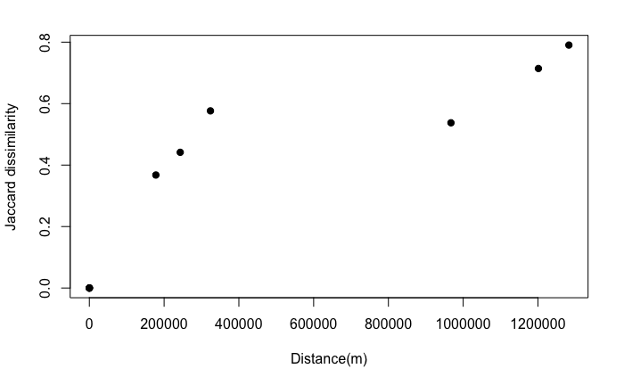

```r
library(reshape2)
#reshape distances
reg_distance.l <- melt(as.matrix(reg_distances), varnames = c("reg1", "reg2")) #matrix to data frame,
reg_distance.l <- data.table(reg_distance.l) #and then to data table
reg_distance.l <- reg_distance.l[reg1 >= reg2,] # to get rid of repetitions
colnames(reg_distance.l)[colnames(reg_distance.l)=="value"] <- "distance(m)" #change column name to distance
#reshape dissimilarities
dissimilarities_1967.l <- melt(as.matrix(dissimilarities_1967), varnames = c("reg1", "reg2"))
dissimilarities_1967.l <- data.table(dissimilarities_1967.l) #and then to data table
dissimilarities_1967.l <- dissimilarities_1967.l[reg1 >= reg2,] # to get rid of repetitions
colnames(dissimilarities_1967.l)[colnames(dissimilarities_1967.l)=="value"] <- "jaccard_dissimilarity" #change column name to distance
#add year for these values
dissimilarities_1967.l[, "YEAR" := 1967]
#merge distance with jaccard_dissimilarity for this year
dissimilarities_1967.l.full <- reg_distance.l[dissimilarities_1967.l, on = c("reg1", "reg2")]
#make plot
plot(x=dissimilarities_1967.l.full$`distance(m)`, y=dissimilarities_1967.l.full$jaccard_dissimilarity, xlab = "Distance(m)", ylab="Jaccard dissimilarity", pch = 19) #this doesn't make sense, going back
```

```r
NA
```

PCA for visual

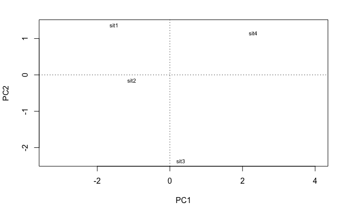

```r
vare.pca <- rda(neus_pres_abs_1year_wide.communitymatrix[,c(1:817)])
plot(vare.pca, display = "sites")
```

Loop for all

```r
distances_dissimilarities_allyears <- data.table("reg1" = integer(), "reg2" = integer(), "distance(m)" = numeric(),"jaccard_dissimilarity" = numeric(), YEAR = integer())
#Now loop through all years starting in 1967
for (i in 1:length(years)) {
  reduced_year <- neus_pres_abs[YEAR == years[i],]
  reduced_year_wide <- dcast(reduced_year, YEAR + reg ~ SCINAME, value.var = "present") #long to wide data for community matrix, column names are SVSPP

  communitymatrix <- cbind(reduced_year_wide[,c(3:819)], reduced_year_wide[,c(1:2)]) #community matrix


  dissimilarities <- vegdist(communitymatrix[,c(1:817)], method = "jaccard") #dissimilarity matrix
  #reshape dissimilarities
  dissimilarities.l <- melt(as.matrix(dissimilarities), varnames = c("reg1", "reg2"))
  dissimilarities.l <- data.table(dissimilarities.l) #and then to data table
  dissimilarities.l <- dissimilarities.l[reg1 >= reg2,] # to get rid of repetitions
  colnames(dissimilarities.l)[colnames(dissimilarities.l)=="value"] <- "jaccard_dissimilarity" #change column name to distance
#add year for these values
  dissimilarities.l[, "YEAR" := years[i]]
#merge distance with jaccard_dissimilarity for this year
  dissimilarities.l.full <- reg_distance.l[dissimilarities.l, on = c("reg1", "reg2")]
distances_dissimilarities_allyears <- rbind(distances_dissimilarities_allyears, dissimilarities.l.full) #add to data table
jpeg(file=paste0("jaccardplot_", years[i], ".jpg"))
    plot(x=dissimilarities.l.full$`distance(m)`, y=dissimilarities.l.full$jaccard_dissimilarity, xlab = "Distance(m)", ylab="Jaccard dissimilarity", ylim = c(0:1), pch = 19)
 dev.off()

 #PCA
vare.pca <- rda(communitymatrix[,c(1:817)])
jpeg(file=paste0("jaccardpca_", years[i], ".jpg"))
plot(vare.pca, display = "sites", xlim = c(-4,4), ylim = c(-4,4))
dev.off()

}
```

Jaccard Dissimilarities Distance Decay all in one plot This plot will be much more interesting with more strata, TO DO tomorrow

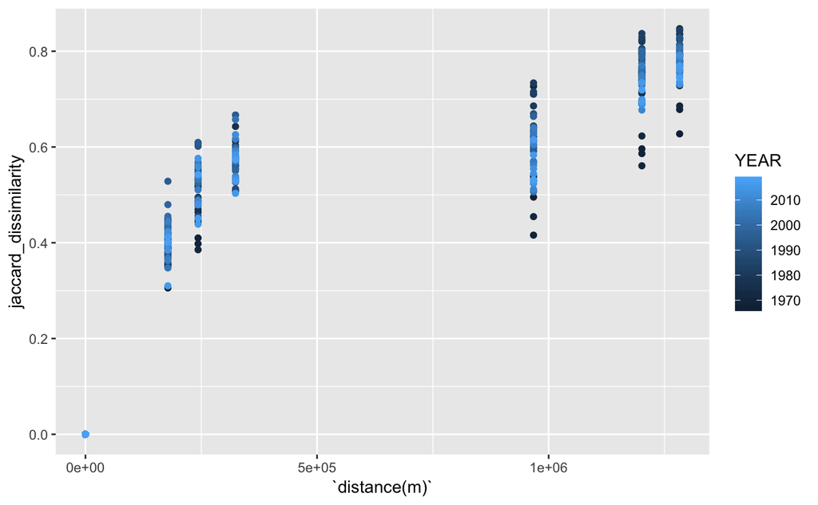

Plot jaccard for 1 and 2 through time

```r
reduced_1_2 <- distances_dissimilarities_allyears[reg1 == 2 & reg2 ==1,]
geo_gme_overtime <- ggplot(data = reduced_1_2, aes(x = YEAR, y = jaccard_dissimilarity)) +
  geom_point() +
  geom_smooth(method = "lm") +
  ylim(0:1) +
  stat_cor(label.y = 0.1, label.x = 1990) +
  stat_regline_equation(label.y = 0.2, label.x = 1990) +
  labs(x= "Year", y = "Jaccard Dissimilarity") +
  ggtitle("GME vs. GEO") +
  theme_classic() +
  theme(text = element_text(size = 20))


ggsave(geo_gme_overtime, file ="GEO & GME Jaccard Through Time.eps")
```

```r
reduced_3_2 <- distances_dissimilarities_allyears[reg1 == 3 & reg2 ==2,]
sne_geo_overtime <- ggplot(data = reduced_3_2, aes(x = YEAR, y = jaccard_dissimilarity)) +
  geom_point() +
  geom_smooth(method = "lm") +
  ylim(0:1) +
  stat_cor(label.y = 0.1, label.x = 1990) +
  stat_regline_equation(label.y = 0.2, label.x = 1990) +
  labs(x= "Year", y = "Jaccard Dissimilarity") +
  ggtitle("SNE vs. GEO") +
  theme_classic() +
  theme(text = element_text(size = 20))


ggsave(sne_geo_overtime, file ="SNE & GEO Jaccard Through Time.eps")
```

Plot jaccard for 1 and 4 through time

```r
reduced_1_4 <- distances_dissimilarities_allyears[reg1 == 4 & reg2 ==1,]
gme_mab_overtime <- ggplot(data = reduced_1_4, aes(x = YEAR, y = jaccard_dissimilarity)) +
  geom_point() +
  geom_smooth(method = "lm") +
  ylim(0:1) +
  stat_cor(label.y = 0.1, label.x = 1990) +
  stat_regline_equation(label.y = 0.2, label.x = 1990) +
  labs(x= "Year", y = "Jaccard Dissimilarity") +
  ggtitle("GME vs. MAB") +
  theme_classic() +
  theme(text = element_text(size = 20))


ggsave(gme_mab_overtime, file ="GME & MAB Jaccard Through Time.eps")
```

Plot jaccard for 2 and 3 through time

```r
reduced_3_2 <- distances_dissimilarities_allyears[reg1 == 3 & reg2 ==2,]
sne_geo_overtime <- ggplot(data = reduced_3_2, aes(x = YEAR, y = jaccard_dissimilarity)) +
  geom_point() +
  geom_smooth(method = "lm") +
  ylim(0:1) +
  stat_cor(label.y = 0.1, label.x = 1990) +
  stat_regline_equation(label.y = 0.2, label.x = 1990) +
  labs(x= "Year", y = "Jaccard Dissimilarity") +
  ggtitle("SNE vs. GEO") +
  theme_classic() +
  theme(text = element_text(size = 20))


ggsave(sne_geo_overtime, file ="SNE & GEO Jaccard Through Time.eps")
```

Plot jaccard for 2 and 4 through time

```r
reduced_4_2 <- distances_dissimilarities_allyears[reg1 == 4 & reg2 ==2,]
mab_geo_overtime <- ggplot(data = reduced_4_2, aes(x = YEAR, y = jaccard_dissimilarity)) +
  geom_point() +
  geom_smooth(method = "lm") +
  ylim(0:1) +
  stat_cor(label.y = 0.1, label.x = 1990) +
  stat_regline_equation(label.y = 0.2, label.x = 1990) +
  labs(x= "Year", y = "Jaccard Dissimilarity") +
  ggtitle("MAB vs. GEO") +
  theme_classic() +
  theme(text = element_text(size = 20))


ggsave(mab_geo_overtime, file ="MAB & GEO Jaccard Through Time.eps")
```

Plot jaccard for 3 and 4 through time

```r
reduced_3_4 <- distances_dissimilarities_allyears[reg1 == 4 & reg2 ==3,]
sne_mab_overtime <- ggplot(data = reduced_3_4, aes(x = YEAR, y = jaccard_dissimilarity)) +
  geom_point() +
  geom_smooth(method = "lm") +
  ylim(0:1) +
  stat_cor(label.y = 0.1, label.x = 1990) +
  stat_regline_equation(label.y = 0.2, label.x = 1990) +
  labs(x= "Year", y = "Jaccard Dissimilarity") +
  ggtitle("SNE vs. MAB") +
  theme_classic() +
  theme(text = element_text(size = 20))


ggsave(sne_mab_overtime, file ="SNE & MAB Jaccard Through Time.eps")
```

Looking at changes in jaccard dissimilarity across time for each region individually

```r
  reduced_region <- neus_pres_abs[reg == "GME",]
  reduced_region_wide <- dcast(reduced_region, YEAR + reg ~ SCINAME, value.var = "present") #long to wide data for community matrix, column names are SVSPP

  communitymatrix_GME <- cbind(reduced_region_wide[,c(3:819)], reduced_region_wide[,c(1:2)]) #community matrix


  dissimilarities_GME <- vegdist(communitymatrix_GME[,c(1:817)], method = "jaccard") #dissimilarity matrix
  #reshape dissimilarities
  dissimilarities.l_GME <- melt(as.matrix(dissimilarities_GME), varnames = c("year1", "year2"))
  dissimilarities.l_GME <- data.table(dissimilarities.l_GME) #and then to data table


  #I only want year 2 to be less than year 1 (don't need all comparisons)
  values_key <- c(1, rep(2:51, each=2), 52)
  year_turnover_key <- matrix(values_key, nrow = 2)
  year_turnover_key <- data.table(year_turnover_key)
  year_turnover_key.t <- transpose(year_turnover_key)
  year_turnover_key.final <- data.table("year1" = year_turnover_key.t[,V2], "year2" = year_turnover_key.t[,V1])

  #combine key with dissimilarities.l_GME
dissimilarities_final_GME <- year_turnover_key.final[dissimilarities.l_GME, on = c("year1","year2"), nomatch = 0]


colnames(dissimilarities_final_GME)[colnames(dissimilarities_final_GME)=="value"] <- "jaccard_dissimilarity"
#change column name to distance
dissimilarities_final_GME[,"YEAR" := years[1:51]]
jpeg(file="jaccard_overtime_GME.jpg")
    plot(x=dissimilarities_final_GME$YEAR, y=dissimilarities_final_GME$jaccard_dissimilarity, xlab = "Year", ylab="Jaccard dissimilarity", ylim = c(0:1), pch = 19)
 dev.off()
```

```r
  reduced_region <- neus_pres_abs[reg == "GME",]
  reduced_region_wide <- dcast(reduced_region, YEAR + reg ~ SCINAME, value.var = "present") #long to wide data for community matrix, column names are SVSPP

  communitymatrix_GME <- cbind(reduced_region_wide[,c(3:819)], reduced_region_wide[,c(1:2)]) #community matrix


  dissimilarities_GME <- vegdist(communitymatrix_GME[,c(1:817)], method = "jaccard") #dissimilarity matrix
  #reshape dissimilarities
  dissimilarities.l_GME <- melt(as.matrix(dissimilarities_GME), varnames = c("year1", "year2"))
  dissimilarities.l_GME <- data.table(dissimilarities.l_GME) #and then to data table


  #I only want to compare years with first year (don't need all comparisons)
  year_turnover_key.firstyear <- data.table("year1" = c(2:52), "year2" = 1)

  #combine key with dissimilarities.l_GME
dissimilarities_final_GME_year1 <- year_turnover_key.firstyear[dissimilarities.l_GME, on = c("year1","year2"), nomatch = 0]


colnames(dissimilarities_final_GME_year1)[colnames(dissimilarities_final_GME_year1)=="value"] <- "jaccard_dissimilarity"
#change column name to distance
dissimilarities_final_GME_year1[,"YEAR" := years[1:51]]
jaccard_overtime_GME_year1comparison <- ggplot(data = dissimilarities_final_GME_year1, aes(x=YEAR, y = jaccard_dissimilarity)) +
  geom_point() +
  geom_smooth(method = "lm") +
  stat_cor(label.y = 0.15, label.x = 1985, size = 8) +
  stat_regline_equation(label.y =0.2, label.x = 1985, size = 8) +
  ggtitle("a. GME") +
  labs(x = "Year", y = "Jaccard dissimilarity") +
  theme_classic() +
  theme(text = element_text(size = 20))
ggsave(jaccard_overtime_GME_year1comparison, file = "jaccard_overtime_GME_year1comparison.eps" )
```

Looking at changes in jaccard dissimilarity across time for each region individually

```r
  reduced_region <- neus_pres_abs[reg == "GEO",]
  reduced_region_wide <- dcast(reduced_region, YEAR + reg ~ SCINAME, value.var = "present") #long to wide data for community matrix, column names are SVSPP

  communitymatrix_GEO <- cbind(reduced_region_wide[,c(3:819)], reduced_region_wide[,c(1:2)]) #community matrix


  dissimilarities_GEO <- vegdist(communitymatrix_GEO[,c(1:817)], method = "jaccard") #dissimilarity matrix
  #reshape dissimilarities
  dissimilarities.l_GEO <- melt(as.matrix(dissimilarities_GEO), varnames = c("year1", "year2"))
  dissimilarities.l_GEO <- data.table(dissimilarities.l_GEO) #and then to data table


  #I only want year 2 to be less than year 1 (don't need all comparisons)
  values_key <- c(1, rep(2:51, each=2), 52)
  year_turnover_key <- matrix(values_key, nrow = 2)
  year_turnover_key <- data.table(year_turnover_key)
  year_turnover_key.t <- transpose(year_turnover_key)
  year_turnover_key.final <- data.table("year1" = year_turnover_key.t[,V2], "year2" = year_turnover_key.t[,V1])

  #combine key with dissimilarities.l_GEO
dissimilarities_final_GEO <- year_turnover_key.final[dissimilarities.l_GEO, on = c("year1","year2"), nomatch = 0]


colnames(dissimilarities_final_GEO)[colnames(dissimilarities_final_GEO)=="value"] <- "jaccard_dissimilarity"
#change column name to distance
dissimilarities_final_GEO[,"YEAR" := years[1:51]]
jpeg(file="jaccard_overtime_GEO.jpg")
    plot(x=dissimilarities_final_GEO$YEAR, y=dissimilarities_final_GEO$jaccard_dissimilarity, xlab = "Year", ylab="Jaccard dissimilarity", ylim = c(0:1), pch = 19)
 dev.off()
```

```r
  reduced_region <- neus_pres_abs[reg == "GEO",]
  reduced_region_wide <- dcast(reduced_region, YEAR + reg ~ SCINAME, value.var = "present") #long to wide data for community matrix, column names are SVSPP

  communitymatrix_GEO <- cbind(reduced_region_wide[,c(3:819)], reduced_region_wide[,c(1:2)]) #community matrix


  dissimilarities_GEO <- vegdist(communitymatrix_GEO[,c(1:817)], method = "jaccard") #dissimilarity matrix
  #reshape dissimilarities
  dissimilarities.l_GEO <- melt(as.matrix(dissimilarities_GEO), varnames = c("year1", "year2"))
  dissimilarities.l_GEO <- data.table(dissimilarities.l_GEO) #and then to data table


  #I only want to compare years with first year (don't need all comparisons)
  year_turnover_key.firstyear <- data.table("year1" = c(2:52), "year2" = 1)

  #combine key with dissimilarities.l_GEO
dissimilarities_final_GEO_year1 <- year_turnover_key.firstyear[dissimilarities.l_GEO, on = c("year1","year2"), nomatch = 0]


colnames(dissimilarities_final_GEO_year1)[colnames(dissimilarities_final_GEO_year1)=="value"] <- "jaccard_dissimilarity"
#change column name to distance
dissimilarities_final_GEO_year1[,"YEAR" := years[1:51]]
jaccard_overtime_GEO_year1comparison <- ggplot(data = dissimilarities_final_GEO_year1, aes(x=YEAR, y = jaccard_dissimilarity)) +
  geom_point() +
  geom_smooth(method = "lm") +
  stat_cor(label.y = 0.15, label.x = 1985, size = 8) +
  stat_regline_equation(label.y =0.2, label.x = 1985, size = 8) +
  ggtitle("b. GEO") +
  labs(x = "Year", y = "Jaccard dissimilarity") +
  theme_classic() +
  theme(text = element_text(size = 20))
ggsave(jaccard_overtime_GEO_year1comparison, file = "jaccard_overtime_GEO_year1comparison.eps" )
```

Looking at changes in jaccard dissimilarity across time for each region individually

```r
  reduced_region <- neus_pres_abs[reg == "SNE",]
  reduced_region_wide <- dcast(reduced_region, YEAR + reg ~ SCINAME, value.var = "present") #long to wide data for community matrix, column names are SVSPP

  communitymatrix_SNE <- cbind(reduced_region_wide[,c(3:819)], reduced_region_wide[,c(1:2)]) #community matrix


  dissimilarities_SNE <- vegdist(communitymatrix_SNE[,c(1:817)], method = "jaccard") #dissimilarity matrix
  #reshape dissimilarities
  dissimilarities.l_SNE <- melt(as.matrix(dissimilarities_SNE), varnames = c("year1", "year2"))
  dissimilarities.l_SNE <- data.table(dissimilarities.l_SNE) #and then to data table


  #I only want year 2 to be less than year 1 (don't need all comparisons)
  values_key <- c(1, rep(2:51, each=2), 52)
  year_turnover_key <- matrix(values_key, nrow = 2)
  year_turnover_key <- data.table(year_turnover_key)
  year_turnover_key.t <- transpose(year_turnover_key)
  year_turnover_key.final <- data.table("year1" = year_turnover_key.t[,V2], "year2" = year_turnover_key.t[,V1])

  #combine key with dissimilarities.l_SNE
dissimilarities_final_SNE <- year_turnover_key.final[dissimilarities.l_SNE, on = c("year1","year2"), nomatch = 0]


colnames(dissimilarities_final_SNE)[colnames(dissimilarities_final_SNE)=="value"] <- "jaccard_dissimilarity"
#change column name to distance
dissimilarities_final_SNE[,"YEAR" := years[1:51]]
jpeg(file="jaccard_overtime_SNE.jpg")
    plot(x=dissimilarities_final_SNE$YEAR, y=dissimilarities_final_SNE$jaccard_dissimilarity, xlab = "Year", ylab="Jaccard dissimilarity", ylim = c(0:1), pch = 19)
 dev.off()
```

```r
  reduced_region <- neus_pres_abs[reg == "SNE",]
  reduced_region_wide <- dcast(reduced_region, YEAR + reg ~ SCINAME, value.var = "present") #long to wide data for community matrix, column names are SVSPP

  communitymatrix_SNE <- cbind(reduced_region_wide[,c(3:819)], reduced_region_wide[,c(1:2)]) #community matrix


  dissimilarities_SNE <- vegdist(communitymatrix_SNE[,c(1:817)], method = "jaccard") #dissimilarity matrix
  #reshape dissimilarities
  dissimilarities.l_SNE <- melt(as.matrix(dissimilarities_SNE), varnames = c("year1", "year2"))
  dissimilarities.l_SNE <- data.table(dissimilarities.l_SNE) #and then to data table


  #I only want to compare years with first year (don't need all comparisons)
  year_turnover_key.firstyear <- data.table("year1" = c(2:52), "year2" = 1)

  #combine key with dissimilarities.l_SNE
dissimilarities_final_SNE_year1 <- year_turnover_key.firstyear[dissimilarities.l_SNE, on = c("year1","year2"), nomatch = 0]


colnames(dissimilarities_final_SNE_year1)[colnames(dissimilarities_final_SNE_year1)=="value"] <- "jaccard_dissimilarity"
#change column name to distance
dissimilarities_final_SNE_year1[,"YEAR" := years[1:51]]
jaccard_overtime_SNE_year1comparison <- ggplot(data = dissimilarities_final_SNE_year1, aes(x=YEAR, y = jaccard_dissimilarity)) +
  geom_point() +
  geom_smooth(method = "lm") +
  stat_cor(label.y = 0.15, label.x = 1985, size = 8) +
  stat_regline_equation(label.y =0.2, label.x = 1985, size = 8) +
  ggtitle("c. SNE") +
  labs(x = "Year", y = "Jaccard dissimilarity") +
  theme_classic() +
  theme(text = element_text(size = 20))
ggsave(jaccard_overtime_SNE_year1comparison, file = "jaccard_overtime_SNE_year1comparison.eps" )
```

Looking at changes in jaccard dissimilarity across time for each region individually

```r
  reduced_region <- neus_pres_abs[reg == "MAB",]
  reduced_region_wide <- dcast(reduced_region, YEAR + reg ~ SCINAME, value.var = "present") #long to wide data for community matrix, column names are SVSPP

  communitymatrix_MAB <- cbind(reduced_region_wide[,c(3:819)], reduced_region_wide[,c(1:2)]) #community matrix


  dissimilarities_MAB <- vegdist(communitymatrix_MAB[,c(1:817)], method = "jaccard") #dissimilarity matrix
  #reshape dissimilarities
  dissimilarities.l_MAB <- melt(as.matrix(dissimilarities_MAB), varnames = c("year1", "year2"))
  dissimilarities.l_MAB <- data.table(dissimilarities.l_MAB) #and then to data table


  #I only want year 2 to be less than year 1 (don't need all comparisons)
  values_key <- c(1, rep(2:51, each=2), 52)
  year_turnover_key <- matrix(values_key, nrow = 2)
  year_turnover_key <- data.table(year_turnover_key)
  year_turnover_key.t <- transpose(year_turnover_key)
  year_turnover_key.final <- data.table("year1" = year_turnover_key.t[,V2], "year2" = year_turnover_key.t[,V1])

  #combine key with dissimilarities.l_MAB
dissimilarities_final_MAB <- year_turnover_key.final[dissimilarities.l_MAB, on = c("year1","year2"), nomatch = 0]


colnames(dissimilarities_final_MAB)[colnames(dissimilarities_final_MAB)=="value"] <- "jaccard_dissimilarity"
#change column name to distance
dissimilarities_final_MAB[,"YEAR" := years[1:51]]
jpeg(file="jaccard_overtime_MAB.jpg")
    plot(x=dissimilarities_final_MAB$YEAR, y=dissimilarities_final_MAB$jaccard_dissimilarity, xlab = "Year", ylab="Jaccard dissimilarity", ylim = c(0:1), pch = 19)
 dev.off()
```

```r
  reduced_region <- neus_pres_abs[reg == "MAB",]
  reduced_region_wide <- dcast(reduced_region, YEAR + reg ~ SCINAME, value.var = "present") #long to wide data for community matrix, column names are SVSPP

  communitymatrix_MAB <- cbind(reduced_region_wide[,c(3:819)], reduced_region_wide[,c(1:2)]) #community matrix


  dissimilarities_MAB <- vegdist(communitymatrix_MAB[,c(1:817)], method = "jaccard") #dissimilarity matrix
  #reshape dissimilarities
  dissimilarities.l_MAB <- melt(as.matrix(dissimilarities_MAB), varnames = c("year1", "year2"))
  dissimilarities.l_MAB <- data.table(dissimilarities.l_MAB) #and then to data table


  #I only want to compare years with first year (don't need all comparisons)
  year_turnover_key.firstyear <- data.table("year1" = c(2:52), "year2" = 1)

  #combine key with dissimilarities.l_MAB
dissimilarities_final_MAB_year1 <- year_turnover_key.firstyear[dissimilarities.l_MAB, on = c("year1","year2"), nomatch = 0]


colnames(dissimilarities_final_MAB_year1)[colnames(dissimilarities_final_MAB_year1)=="value"] <- "jaccard_dissimilarity"
#change column name to distance
dissimilarities_final_MAB_year1[,"YEAR" := years[1:51]]
jaccard_overtime_MAB_year1comparison <- ggplot(data = dissimilarities_final_MAB_year1, aes(x=YEAR, y = jaccard_dissimilarity)) +
  geom_point() +
  geom_smooth(method = "lm") +
  stat_cor(label.y = 0.15, label.x = 1985, size = 8) +
  stat_regline_equation(label.y =0.2, label.x = 1985, size = 8) +
  ggtitle("d. MAB") +
  labs(x = "Year", y = "Jaccard dissimilarity") +
  theme_classic() +
  theme(text = element_text(size = 20))
ggsave(jaccard_overtime_MAB_year1comparison, file = "jaccard_overtime_MAB_year1comparison.eps" )
```

Simplified species richness through time

```r
library(ggplot2)
library(ggpubr)
GME_spp_richness <- rowSums(communitymatrix_GME[,1:817])
GEO_spp_richness <- rowSums(communitymatrix_GEO[,1:817])
SNE_spp_richness <- rowSums(communitymatrix_SNE[,1:817])
MAB_spp_richness <- rowSums(communitymatrix_MAB[,1:817])
spp_richness <- data.table("year" = years, "GME" = GME_spp_richness, "GEO" = GEO_spp_richness, "SNE" = SNE_spp_richness, "MAB" = MAB_spp_richness)
spp_richness.l <- melt(spp_richness, id.vars = c("year"),
                measure.vars = c("GME", "GEO", "SNE", "MAB"),
                value.name = "richness")
species_richness_reg <- ggplot(data = spp_richness.l, aes(x = year, y=richness)) +
  geom_line() +
  ylim(0,350) +
  geom_smooth(method = lm) +
  facet_wrap(~variable) +
  stat_cor(label.y = 0, label.x = 1990) +
  stat_regline_equation(label.y = 50, label.x = 1990) +
  theme_classic()
ggsave(species_richness_reg, file = "species_richness_reg.eps")
```

# Distance Decay with Stratum instead of region

Jaccard Dissimilarities Distance Decay all in one plot by STRATA

```r
neus_full.ID.uniquestrata <- unique(neus_full.ID, by = "STRATUM") #unique strata
neus_full.ID.uniquestrata.latlon <- neus_full.ID.uniquestrata[,c(1,6,7)] #only lat lon and stratum
stratum_distances <- distm(neus_full.ID.uniquestrata.latlon[,c(3, 2)]) #distance matrix, consistent across years
rownames(stratum_distances) <- neus_full.ID.uniquestrata.latlon$STRATUM
colnames(stratum_distances) <- neus_full.ID.uniquestrata.latlon$STRATUM
#reorient to long form
stratum_distance.l <- melt(as.matrix(stratum_distances), varnames = c("strat1", "strat2")) #matrix to data frame,
stratum_distance.l <- data.table(stratum_distance.l) #and then to data table
stratum_distance.l <- stratum_distance.l[strat1 >= strat2,] # to get rid of repetitions
colnames(stratum_distance.l)[colnames(stratum_distance.l)=="value"] <- "distance(m)" #change column name to distance
```

Above is distance info, now I need to build community matrix

```r
neus_full.ID
```

| STRATUM | SVSPP | CATCHSEX | YEAR | SEASON | LAT | LON | STRATUM_NAME | MIDLAT | MIDLON | SCINAME | COMNAME |
| --- | --- | --- | --- | --- | --- | --- | --- | --- | --- | --- | --- |
| 1020 | 1 | 0 | 1974 | SPRING | 39.73333 | -72.85000 | SNE HUDSON CANYN | 3942 | 7246 | MYXINE GLUTINOSA | ATLANTIC HAGFISH |
| 1030 | 1 | 0 | 2016 | FALL | 39.82302 | -71.90662 | SNE HUDSON CANYN | 3925 | 7226 | MYXINE GLUTINOSA | ATLANTIC HAGFISH |
| 1040 | 1 | 0 | 1965 | FALL | 39.73333 | -71.85000 | SNE HUDSON CANYN | 3920 | 7216 | MYXINE GLUTINOSA | ATLANTIC HAGFISH |
| 1040 | 1 | 0 | 1965 | FALL | 39.73333 | -71.85000 | SNE HUDSON CANYN | 3920 | 7216 | MYXINE GLUTINOSA | ATLANTIC HAGFISH |
| 1040 | 1 | 0 | 1966 | FALL | 39.20000 | -72.50000 | SNE HUDSON CANYN | 3920 | 7216 | MYXINE GLUTINOSA | ATLANTIC HAGFISH |
| 1040 | 1 | 0 | 1969 | FALL | 39.80000 | -71.80000 | SNE HUDSON CANYN | 3920 | 7216 | MYXINE GLUTINOSA | ATLANTIC HAGFISH |
| 1040 | 1 | 0 | 1969 | FALL | 39.80000 | -71.80000 | SNE HUDSON CANYN | 3920 | 7216 | MYXINE GLUTINOSA | ATLANTIC HAGFISH |
| 1040 | 1 | 0 | 1970 | SPRING | 39.50000 | -72.35000 | SNE HUDSON CANYN | 3920 | 7216 | MYXINE GLUTINOSA | ATLANTIC HAGFISH |
| 1040 | 1 | 0 | 1970 | SPRING | 39.50000 | -72.35000 | SNE HUDSON CANYN | 3920 | 7216 | MYXINE GLUTINOSA | ATLANTIC HAGFISH |
| 1040 | 1 | 0 | 1972 | SPRING | 39.28333 | -72.33333 | SNE HUDSON CANYN | 3920 | 7216 | MYXINE GLUTINOSA | ATLANTIC HAGFISH |

[output cut: 990 more lines]

```r
#one PRESENT value for each YEAR, SEASON, STRATUM and SVSPP combination
neus_full.ID.stratum.unique <- na.omit(unique(neus_full.ID, by = c("YEAR", "STRATUM", "SVSPP")), cols = c("YEAR", "STRATUM", "SVSPP")) #unique STRATUM, year, species combinations, and get rid of any rows where any are NA
#reduce data table to just be svspp, year, sciname, comname, STRATUM
neus_full.ID.stratum.unique.r <- data.table((neus_full.ID.stratum.unique[, c("SVSPP", "SCINAME", "COMNAME", "YEAR", "STRATUM")]))
#add presence column
neus_full.ID.stratum.unique.r[,"present" := 1]
#now I need to populate a comparison data table with every possible year, region, and species combination to add 0s
stratum <- as.integer(unique(neus_full.ID.stratum.unique.r$STRATUM))
table(neus_full.ID.stratum.unique.r$STRATUM, neus_full.ID.regions.unique.r$present)
```

```
Error in table(neus_full.ID.stratum.unique.r$STRATUM, neus_full.ID.regions.unique.r$present) :
  all arguments must have the same length
```

Bring in presences to expansion for presence by STRATUM

```r
merge <- neus_full.ID.stratum.unique.r[full_set_stratum, on = c("YEAR", "STRATUM", "SVSPP")]
merge[,"present" := ifelse(is.na(SCINAME), 0,1)][,"SCINAME" := NULL][,"COMNAME" := NULL] #if scientific name and common name are empty, that is an absence, if populated, presence, also, we don't need these columns, as we'll bring them in below
#simplify spp key
#bring in spp key
spp_key
```

| SCINAME | SVSPP | COMNAME |
| --- | --- | --- |
| MYXINE GLUTINOSA | 1 | ATLANTIC HAGFISH |
| PETROMYZON MARINUS | 2 | SEA LAMPREY |
| CARCHARHINUS OBSCURUS | 3 | DUSKY SHARK |
| DASYATIS CENTROURA | 4 | ROUGHTAIL STINGRAY |
| RAJIFORMES | 5 | RAY AND SKATE UNCL |
| CETORHINUS MAXIMUS | 6 | BASKING SHARK |
| CENTROSCYLLIUM FABRICII | 7 | BLACK DOGFISH |
| ETMOPTERUS PRINCEPS | 8 | ROUGH SAGRE |
| CARCHARHINUS PLUMBEUS | 9 | SANDBAR SHARK |
| SELACHIMORPHA | 11 | SHARK UNCL |

[output cut: 807 more lines]

```r
neus_pres_abs_STRATUM <- merge[spp_key, on = c("SVSPP")] #also don't actually need all columns
```

Loop for all STRATUM, YEAR, SVSPP combos

```r
load(distances_dissimilarities_allyears_STRATUM)
```

```
Error in load(distances_dissimilarities_allyears_STRATUM) :
  bad 'file' argument
```

Now, let’s see what plots look like for distance decay over time

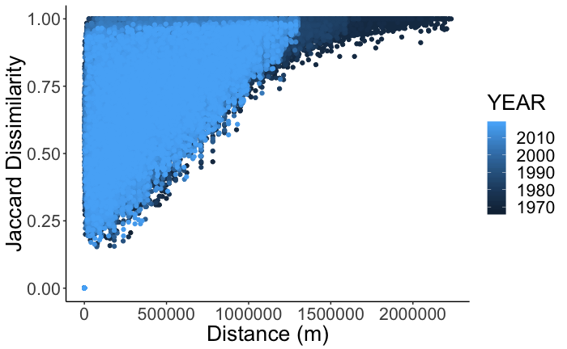

Extract coefficient (slope) for each year, how does it change through time?

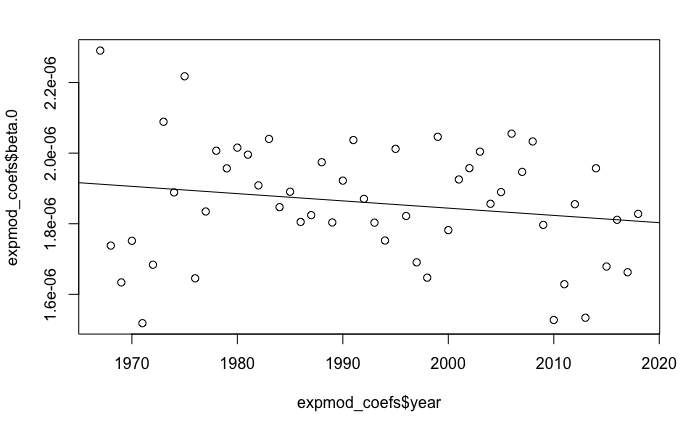

Fitting distance decay models to pair-wise assemblage similarity: fits a negative exponential or power law function(GLM) describing decay of assemblage similarity or increase of dissimilarity with distance.

```r
mod_1968 <- decay.model(dissimilarities.m, stratum_distances.r)
```

```
Error in eval(family$initialize) :
  cannot find valid starting values: please specify some
```